# Trust in Courts, Trust in Credit?

An econometrics notebook on institutions and business lending

MBA Econometrics · Research notebook

**Do firms tend to have more credit in countries where managers trust the courts to be fair?** A lender may be more willing to lend when it expects a fair hearing and can enforce a contract. We use the World Bank Enterprise Surveys to check whether the countries line up that way.

**163**economies in the core model

**0.60 pp**credit difference per 10 points more confidence, before adjustment

**-0.67 pp**same comparison after allowing for bribery and firm size

**-1.20 pp**comparison within the same region and survey year

**Short answer.** We found no clear evidence that countries where firms trust the courts more have more firms holding credit. The estimates are small, change direction when we account for other differences, and are uncertain. Start with the country examples and the simple checks below. **Show** reveals the R behind an exhibit. The later sections explain the methods in more detail.

**Contents**

# 1 The country comparison in plain English

## 1.1 Can we compare countries and court systems?

**Why this data?** The Enterprise Surveys ask comparable questions of firms in different economies. We use the national reply summary for the court-impartiality question and the share of firms with a loan or line of credit from the same survey wave. We flip the published doubt index so that the **confidence score** goes up when managers view courts more favorably. More confidence and more credit are each easier to read in the same direction. [World Bank country survey data](https://www.enterprisesurveys.org/en/data), [indicator guide](https://www.enterprisesurveys.org/content/dam/enterprisesurveys/documents/methodology/Indicator-Description.pdf)

**What it means.** The score describes opinions about the courts of an economy, as reported by eligible formal firms. Individual courts, judges, cases and loan applications are outside these aggregates. The World Bank’s separate Business Ready project collects measures such as litigation time and enforcement cost. Those answer a different question about court performance and are outside the Enterprise Surveys regression used here. [World Bank Business Ready dispute-resolution methods](https://www.worldbank.org/en/businessready/about-us/faq)

**Look up an economy in the study sample**

```r
# These are the same national, same-wave inputs used in the regressions.
# The World Bank confidence measure is an index. Other columns are percentages.
tab(court_country_profiles, "Country lookup · court confidence, credit and related survey measures", digits = 1)
```

Country lookup · court confidence, credit and related survey measures

| Economy | Code | Region | Wave | Confidence | Credit | Severe obstacle | Bribery | Fully constrained |
| --- | --- | --- | --- | --- | --- | --- | --- | --- |
| Afghanistan | AFG | Middle East, North Africa, Afghanistan & Pakistan | 2025 | 73.4 | 21.5 | 7.6 | 9.5 | 19.5 |
| Albania | ALB | Europe & Central Asia | 2025 | 64.3 | 22.8 | 17.6 | 15.1 | 5.5 |
| Angola | AGO | Sub-Saharan Africa | 2024 | 78.8 | 7.4 | 10.8 | 21.5 | 57.2 |
| Antigua and Barbuda | ATG | Latin America & Caribbean | 2025 | 44.4 | 33.0 | 5.5 | 5.5 | 7.6 |
| Argentina | ARG | Latin America & Caribbean | 2026 | 65.9 | 57.2 | 15.8 | 12.5 | 11.6 |
| Armenia | ARM | Europe & Central Asia | 2024 | 63.7 | 48.6 | 2.9 | 0.2 | 16.3 |
| Australia | AUS | East Asia & Pacific | 2025 | 92.6 | 63.0 | 4.6 | 2.5 | 1.4 |
| Austria | AUT | Europe & Central Asia | 2025 | 97.1 | 66.4 | 2.0 | 2.5 | 8.1 |
| Azerbaijan | AZE | Europe & Central Asia | 2024 | 79.6 | 36.4 | 0.1 | 0.7 | 30.7 |
| Bahrain | BHR | Middle East, North Africa, Afghanistan & Pakistan | 2024 | 91.5 | 37.3 | 4.3 | 4.3 | 13.6 |
| Bangladesh | BGD | South Asia | 2022 | 78.5 | 42.5 | 1.2 | 23.0 | 8.0 |
| Barbados | BRB | Latin America & Caribbean | 2023 | 94.5 | 26.9 | 4.2 | 0.0 | 8.5 |
| Belgium | BEL | Europe & Central Asia | 2025 | 86.4 | 74.8 | 3.8 | 5.7 | 1.0 |
| Belize | BLZ | Latin America & Caribbean | 2025 | 74.5 | 50.0 | 2.1 | 10.8 | 7.8 |
| Benin | BEN | Sub-Saharan Africa | 2024 | 64.5 | 40.9 | 20.2 | 11.4 | 9.0 |
| Bhutan | BTN | South Asia | 2024 | 98.1 | 44.3 | 0.8 | 0.3 | 3.8 |
| Bolivia | BOL | Latin America & Caribbean | 2025 | 28.5 | 43.2 | 42.7 | 14.6 | 17.6 |
| Bosnia and Herzegovina | BIH | Europe & Central Asia | 2023 | 33.5 | 43.0 | 4.8 | 3.5 | 4.9 |
| Botswana | BWA | Sub-Saharan Africa | 2023 | 68.3 | 23.1 | 5.5 | 6.1 | 20.4 |
| Brazil | BRA | Latin America & Caribbean | 2025 | 67.7 | 57.6 | 23.4 | 9.8 | 7.6 |
| Brunei Darussalam | BRN | East Asia & Pacific | 2025 | 87.7 | 29.3 | 1.3 | 3.3 | 11.6 |
| Bulgaria | BGR | Europe & Central Asia | 2023 | 59.1 | 31.4 | 7.7 | 0.9 | 8.2 |
| Burkina Faso | BFA | Sub-Saharan Africa | 2024 | 68.6 | 17.3 | 36.6 | 14.1 | 17.6 |
| Burundi | BDI | Sub-Saharan Africa | 2025 | 63.2 | 23.7 | 3.9 | 14.0 | 6.3 |
| Cabo Verde | CPV | Sub-Saharan Africa | 2024 | 68.5 | 19.4 | 20.8 | 1.4 | 16.0 |
| Cambodia | KHM | East Asia & Pacific | 2023 | 74.8 | 13.5 | 0.1 | 27.1 | 4.1 |
| Cameroon | CMR | Sub-Saharan Africa | 2024 | 53.2 | 52.2 | 32.7 | 21.7 | 15.2 |
| Canada | CAN | North America | 2024 | 86.2 | 56.4 | 1.8 | 5.8 | 3.0 |
| Central African Republic | CAF | Sub-Saharan Africa | 2023 | 74.0 | 8.9 | 26.7 | 22.6 | 14.7 |
| Chad | TCD | Sub-Saharan Africa | 2023 | 71.7 | 9.3 | 15.2 | 34.3 | 43.8 |

[output cut: 133 more lines]

The credit, bribery, serious-obstacle and full-constraint columns are percentages from national survey estimates. The confidence column is a score out of 100. The lookup uses the archived study waves.

## 1.2 What do actual countries show?

**Why compare peers?** Start with countries surveyed in the same broad region and year. This lets us hold broad geography and timing fixed as we compare the pattern. For each of the four largest eligible groups from distinct regions, R selects economies near the lower and upper confidence quartiles. No credit outcome enters the selection rule.

```r
# Show one comparable-year pair per selected region. Use the exact scores
# in calculations and round only to label the exhibit.
pair_label <- function(country, score) sprintf("%s (%.1f)", country, score)
tab(data.frame(
  Wave = court_pairs$Wave,
  "Lower confidence (score)" = pair_label(court_pairs$Lower_confidence, court_pairs$Lower_score),
  "Credit %" = court_pairs$Lower_credit,
  "Higher confidence (score)" = pair_label(court_pairs$Higher_confidence, court_pairs$Higher_score),
  "Credit %" = court_pairs$Higher_credit,
  "Credit gap (pp)" = court_pairs$Credit_difference, check.names = FALSE
), "Four same-region, same-year comparisons · credit gap is higher score minus lower score", digits = 1)
```

Four same-region, same-year comparisons · credit gap is higher score minus lower score

| Wave | Lower confidence (score) | Credit % | Higher confidence (score) | Credit % | Credit gap (pp) |
| --- | --- | --- | --- | --- | --- |
| 2024 | Armenia (63.7) | 48.6 | Spain (86.4) | 61.7 | 13.0 |
| 2025 | Guinea (50.6) | 4.9 | Niger (76.2) | 16.4 | 11.5 |
| 2025 | Brazil (67.7) | 57.6 | Trinidad and Tobago (75.5) | 28.6 | -28.9 |
| 2023 | Cambodia (74.8) | 13.5 | New Zealand (89.7) | 53.0 | 39.4 |

**What we found.** Spain scores higher than Armenia and has more firms holding credit. Trinidad and Tobago scores higher than Brazil and has fewer. The pairs point in different directions.

**What it means.** Court confidence and credit can move together, but the higher-confidence country can have less credit. Country stories illustrate the question. For an answer across the data, use all eligible comparisons and report their uncertainty.

## 1.3 Does the pattern hold across countries?

**Why run the analysis this way?** First group countries by their confidence score and look at average credit. Then ask what a ten-point score difference corresponds to, first on its own and then among countries with comparable observed bribery and average employment. The tighter check compares countries inside the same region and survey year. It uses groups of at least four economies and repeats the prior model on those same rows so a change can be separated from a change in sample.

```r
# A descriptive check that does not assume the pattern is a straight line.
tab(court_quartiles[c("Group", "N", "Confidence", "Credit")],
    "Average credit across four ranked confidence groups · Q1 is lowest", digits = 1)
```

Average credit across four ranked confidence groups · Q1 is lowest

| Group | N | Confidence | Credit |
| --- | --- | --- | --- |
| Q1 | 40 | 50.6 | 35.1 |
| Q2 | 41 | 71.3 | 34.3 |
| Q3 | 41 | 79.8 | 36.2 |
| Q4 | 41 | 92.4 | 40.2 |

```r
# The estimate and interval are in percentage points per 10 confidence points.
# The last row changes the outcome to the share of fully credit-constrained firms.
tab(plain_effects(court_effects), "How much does the outcome differ for ten points more confidence?")
```

How much does the outcome differ for ten points more confidence?

| Comparison | Economies | Estimate | 95% interval | p |
| --- | --- | --- | --- | --- |
| Confidence alone | 163 | 0.60 | [-1.39, 2.59] | 0.552 |
| Add bribery and firm size | 163 | -0.67 | [-2.41, 1.07] | 0.449 |
| Same peer sample, without peer controls | 144 | -1.03 | [-2.92, 0.85] | 0.280 |
| Compare within region and survey year | 144 | -1.20 | [-3.09, 0.69] | 0.212 |
| Use full credit constraint as outcome | 163 | -0.01 | [-1.27, 1.25] | 0.986 |

**What we found.** The raw comparison is 0.60 percentage points more credit per ten confidence points. After allowing for bribery and firm size it is -0.67 points. The same-region, same-year result is -1.20 points, with an interval of [-3.09, 0.69]. All three intervals include zero. Looking for steps between the confidence groups also gives little evidence of an association after adjustment. Their joint test has $p=$ 0.748. The alternate outcome, full credit constraint, gives an estimate close to zero.

**What it means.** The sign of the raw comparison is consistent with the lending story. That pattern does not hold up across the adjusted models. The intervals leave room for modest differences under those models. The evidence gives us no reliable basis for forecasting how widespread credit is from this national confidence score.

## 1.4 What happens when we compare a country with itself?

**Why try it?** Countries differ in long-standing ways. Comparing two survey waves for the same economy removes its fixed differences from the change comparison. The archived impartiality question is observed only once per economy. For this separate check we use an older question on whether courts are a **major or very severe obstacle** to business. We compare the latest two usable waves for economies in the main sample, with the earlier wave in 2013 or later for the main repeat-wave fit.

```r
tab(court_time_coverage, "How often the two court measures can be compared over time", digits = 0)
```

How often the two court measures can be compared over time

| Measure | Economies | Repeat economies |
| --- | --- | --- |
| Court confidence | 163 | 0 |
| Severe court obstacle | 181 | 147 |

```r
# One difference per economy. Positive Fewer_obstacles means a decline in the
# percentage of firms rating courts a serious obstacle.
tab(plain_effects(court_change_effects), "Change in credit per ten-point decline in the share reporting severe court obstacles")
```

Change in credit per ten-point decline in the share reporting severe court obstacles

| Comparison | Economies | Estimate | 95% interval | p |
| --- | --- | --- | --- | --- |
| Change in obstacles alone (earlier wave 2013+) | 108 | -1.16 | [-4.27, 1.96] | 0.464 |
| Add changes in bribery, size and years between waves | 108 | -0.61 | [-3.92, 2.71] | 0.717 |
| Allow older earlier waves | 137 | -0.05 | [-2.89, 2.80] | 0.974 |
| Restrict both waves to 2016 or later | 82 | 0.21 | [-3.25, 3.68] | 0.904 |

**What we found.** In 108 economies with two usable waves under the main date rule, a ten-point decline in the share of firms calling courts a serious obstacle corresponds to -0.61 points of change in credit holding after allowing for changes in bribery, firm size and the wave gap. The interval, [-3.92, 2.71], covers credit declines and gains. The other date windows also leave the direction uncertain.

**What it means.** The repeat waves show no clear pattern for the obstacle question. The question measures whether courts disrupt business. The national surveys can interview a changing mix of firms, and economic conditions can change between waves. This check tells us about changes in reported obstacles and credit, with those limits.

## 1.5 What should a manager take away?

**Bribery.** The basic adjusted model associates ten points more bribery with -7.06 points in credit holding. With geography, survey cohort and firm website use included, the estimate is -1.43 points and its interval includes zero. Bribery is a stronger correlate in the simpler model. The size of that association depends on what we compare.

**Legal origin.** The comparison by historical legal family is imprecise. It offers little guidance for a lender choosing between markets. Both the court score and the legal-origin category are broad indicators.

**Decision.** Before pricing a loan or recommending a reform, measure enforcement and lending directly. The useful operational questions are how long recovery takes, how much a lender recovers, who applies for credit, and where applications are declined. The survey gives a country comparison of credit already held.

# 2 The lending question

## 2.1 What would connect courts, bribery and credit?

A bank cares about whether a claim can be enforced, how long recovery takes and what can be recovered. The survey observes what firm managers say about impartiality. These views might contain information about enforcement, and they might also reflect difficult experiences, expectations or who encounters the courts. In related work, Visaria studies the staggered introduction of debt recovery tribunals in India and finds changes in delinquency and interest rates on larger loans. That design uses variation in the timing and applicability of a reform. Here we compare economy-level survey aggregates. [Visaria, *American Economic Journal: Applied Economics*](https://www.aeaweb.org/articles?id=10.1257/app.1.3.59)

**Institutional exposure**Court perceptions and bribe requests during public transactions

*→*

**Possible mechanisms**Recovery risk, operating costs and incentives to apply for credit

*→*

**Observed outcome**Share of firms holding a loan or line of credit

**A confounding route**

Income, banking development and state capacity can move both institutional indicators and credit holding. Credit conditions can also change how firms operate and what they report. The arrows above are hypotheses about mechanisms. The regression estimates how the aggregates move together.

Legal origin asks a different question from measured court perceptions. It classifies the historical origin of company law or the commercial code. Colonial history and other persistent economic differences can overlap with the classification, so a difference by origin has several possible explanations. [Klerman et al., *Journal of Legal Analysis*](https://doi.org/10.1093/jla/lar002)

## 2.2 What does each row and variable represent?

The survey samples eligible establishments in formal nonagricultural sectors. The World Bank uses firm-level survey weights to report national indicators. Here one observation represents one **economy at one survey wave**, and OLS gives every economy the same weight. An estimated difference of five percentage points concerns the share of firms in otherwise comparable observed economies. It cannot tell us how the probability for an individual firm would change if that firm’s exposure changed. [World Bank survey methodology](https://www.enterprisesurveys.org/en/methodology)

```r
# Use descriptive names to keep a percentage, an index, and a dummy distinct.
dictionary <- data.frame(
  Code = c("FIN14", "BREADY_DISP3", "GRAFT3", "WK21", "common", "CRIME9", "DISP2",
           "FIN11", "FIN20", "DISP1", "FIN23", "T5"),
  Measure = c("Loan or line from a financial institution", "Disagreement about court independence and impartiality",
              "At least one bribe request in the covered public transactions", "Average permanent full-time-equivalent employment",
              "English common-law origin", "Courts rated a major or very severe obstacle",
              "Use of courts, arbitration, mediation or conciliation among firms reporting a dispute",
              "Collateral required on the latest loan or line among borrowing firms",
              "Sufficient funds reported as the reason for not applying", "Firms reporting commercial disputes",
              "Firms classified as fully credit constrained", "Firms with their own website"),
  Scale = c("% of firms", "0–100 index", "% of firms", "Workers, then log",
            "0 / 1 where coded", "% of firms", "% within eligible group", "% within eligible group",
            "% of firms", "% of firms", "% of firms", "% of firms"),
  Use = c("Outcome", "Core court measure", "Core bribery measure", "Core control",
          "Legal-origin extension", "Alternative court measure", "Pitch extension",
          "Pitch extension", "Pitch extension", "Pitch extension",
          "Alternative outcome", "Development sensitivity")
)
tab(dictionary, "Measurement map · archived World Bank indicators and the QoG classification")
```

Measurement map · archived World Bank indicators and the QoG classification

| Code | Measure | Scale | Use |
| --- | --- | --- | --- |
| FIN14 | Loan or line from a financial institution | % of firms | Outcome |
| BREADY_DISP3 | Disagreement about court independence and impartiality | 0–100 index | Core court measure |
| GRAFT3 | At least one bribe request in the covered public transactions | % of firms | Core bribery measure |
| WK21 | Average permanent full-time-equivalent employment | Workers, then log | Core control |
| common | English common-law origin | 0 / 1 where coded | Legal-origin extension |
| CRIME9 | Courts rated a major or very severe obstacle | % of firms | Alternative court measure |
| DISP2 | Use of courts, arbitration, mediation or conciliation among firms reporting a dispute | % within eligible group | Pitch extension |
| FIN11 | Collateral required on the latest loan or line among borrowing firms | % within eligible group | Pitch extension |
| FIN20 | Sufficient funds reported as the reason for not applying | % of firms | Pitch extension |
| DISP1 | Firms reporting commercial disputes | % of firms | Pitch extension |
| FIN23 | Firms classified as fully credit constrained | % of firms | Alternative outcome |
| T5 | Firms with their own website | % of firms | Development sensitivity |

FIN14 is a stock measured at the survey. It can reflect borrowing demand, approval, the duration of loans and decisions made in earlier years. GRAFT3 concerns bribe requests in specified public transactions, with refusals coded as positive in the published indicator. It gives us a measure of firms’ operating environment. The data do not tell us that a lender requested a bribe. [World Bank indicator descriptions](https://www.enterprisesurveys.org/content/dam/enterprisesurveys/documents/methodology/Indicator-Description.pdf)

# 3 Build the cross-section

## 3.1 Find the national row

Data360 stores one observation per indicator and **dimension combination**. For the same year and economy, there can be a national figure, exporter figures and figures for other subsets. These subsets can overlap. A simple mean of the published rows would silently substitute a different population for the national aggregate.

```r
# Read dimension codes as text. The raw observations remain untouched.
raw_credit <- read.csv(raw_files[["FIN14"]], colClasses = "character",
                       fileEncoding = "UTF-8-BOM", check.names = FALSE)

# A national row has "_T" in all six relevant dimensions at once.
is_national <- Reduce("&", lapply(raw_credit[total_dimensions], function(x) {
  !is.na(x) & x == "_T"
}))
example <- subset(raw_credit, REF_AREA == "AFG" & TIME_PERIOD == "2008")
first_rows <- head(example[c("REF_AREA", "TIME_PERIOD", "COMP_BREAKDOWN_3",
                             "COMP_BREAKDOWN_3_LABEL", "OBS_VALUE")], 4)
names(first_rows) <- c("Economy", "Wave", "Breakdown code", "Breakdown", "Reported %")
first_rows[["Reported %"]] <- as.numeric(first_rows[["Reported %"]])
tab(first_rows, "A raw FIN14 example · national and subgroup rows")
```

A raw FIN14 example · national and subgroup rows

| Economy | Wave | Breakdown code | Breakdown | Reported % |
| --- | --- | --- | --- | --- |
| AFG | 2008 | _T | Total | 3.37 |
| AFG | 2008 | WB_ES_OTHER_1 | Additional Breakdowns : Exporter Type - Direct exports are 10% or more of sales | 9.09 |
| AFG | 2008 | WB_ES_OTHER_2 | Additional Breakdowns : Exporter Type - Non-exporter | 3.28 |
| AFG | 2008 | WB_ES_OTHER_3 | Additional Breakdowns : Gender of Top Manager - Top manager is female | 0.00 |

```r
# Check the teaching filter against the audited production selection.
stopifnot(sum(is_national) == nrow(national[["FIN14"]]))
```

The pipeline checks normal status, unit multiplier, period format and uniqueness among the selected rows. A duplicate at the economy–year level would require a data decision before a join. It would be unsafe to keep the first row or let an ambiguous merge multiply observations.

```r
# Raw versus national row counts show what the filter does across indicators.
audit_columns <- c("code", "rows", "national", "observed", "first", "last")
audit_display <- source_audit[match(pitch_codes, source_audit$code), audit_columns]
names(audit_display) <- c("Code", "Raw rows", "National rows", "Values", "First wave", "Last wave")
tab(audit_display, "Coverage of the pitch indicators before aligning waves", digits = 0)
```

Coverage of the pitch indicators before aligning waves

| Code | Raw rows | National rows | Values | First wave | Last wave |
| --- | --- | --- | --- | --- | --- |
| FIN14 | 5512 | 469 | 469 | 2006 | 2026 |
| BREADY_DISP3 | 1950 | 163 | 163 | 2021 | 2026 |
| CRIME9 | 5513 | 469 | 469 | 2006 | 2026 |
| DISP2 | 1904 | 163 | 163 | 2021 | 2026 |
| GRAFT3 | 5518 | 470 | 470 | 2006 | 2026 |
| FIN11 | 5463 | 468 | 468 | 2006 | 2026 |
| FIN20 | 5505 | 468 | 468 | 2006 | 2026 |
| WK21 | 5524 | 470 | 470 | 2006 | 2026 |
| DISP1 | 1952 | 163 | 163 | 2021 | 2026 |

## 3.2 Join on economy and wave

`REF_AREA` identifies the economy and `TIME_PERIOD` provides the wave-year key in this archive. The join needs both. Joining on the economy alone could attach an older observation of credit to a newer observation of court doubt. The audited build first lays out the union of economy–year keys, then merges the national indicator values. The latest observed FIN14 wave anchors the cross-section. The latest wave in the union provides a separate check that the anchor does not skip a newer archived observation for an economy.

**Filter**All six breakdown codes equal `_T`

*→*

**Align**One row per economy and wave year

*→*

**Select**Latest observed credit wave, then apply the recent-wave cutoff

```r
# Show the ordered Ghana history, including waves with no DISP3 observation.
ghana <- panel[panel$economy == "GHA", c("year", "FIN14", "BREADY_DISP3", "GRAFT3")]
ghana$Selected <- ifelse(ghana$year == study$year[study$economy == "GHA"], "Core wave", "")
tab(ghana, "One economy through the join · Ghana (GHA)")
```

One economy through the join · Ghana (GHA)

| year | FIN14 | BREADY_DISP3 | GRAFT3 | Selected |
| --- | --- | --- | --- | --- |
| 2007 | 22.18 | NA | 23.01 |  |
| 2013 | 23.33 | NA | 18.74 |  |
| 2023 | 21.88 | 25.94 | 16.96 | Core wave |

```r
stopifnot(!anyDuplicated(panel[c("economy", "year")]), !anyDuplicated(study$economy))
```

The check finds **0** differences between the two latest-wave rules. The cutoff retains surveys from 2021 onward. Older surveys offer additional coverage for some variables, but the court-impartiality series and survey instruments have a narrower comparable time span. Even within the recent sample, survey vintage can matter. Cohort indicators and more recent cutoffs come back as sensitivity checks.

## 3.3 Account for what drops out

```r
# QoG coverage affects the legal-origin estimates. The core sample is broader.
tab(coverage, "Sample accounting · alternative coverage rules", digits = 0)
```

Sample accounting · alternative coverage rules

| Sample | N |
| --- | --- |
| Latest FIN14, all years | 181 |
| Latest WB_ES union, all years | 181 |
| Latest FIN14, 2021+ | 163 |
| Latest joint pitch WB_ES wave, 2021+ | 163 |
| Complete pitch WB_ES cases, 2021+ | 163 |
| QoG code known, 2021+ | 129 |
| English or named civil-code origin, 2021+ | 119 |
| Latest FIN14, 2023+ | 158 |
| Latest FIN14, 2024+ | 113 |

```r
# Count blanks after the wave join so a zero never masquerades as a missing cell.
audit_vars <- c(pitch_codes, "FIN23", "T5", "common")
missing_counts <- function(data) colSums(is.na(data[audit_vars]))
tab(data.frame(Measure = term_labels(audit_vars),
               Earlier = unname(missing_counts(subset(anchor, year < 2021))),
               Recent = unname(missing_counts(study))),
    "Missing observations at the latest wave by vintage group", digits = 0)
```

Missing observations at the latest wave by vintage group

| Measure | Earlier | Recent |
| --- | --- | --- |
| Credit holding | 0 | 0 |
| Court doubt | 18 | 0 |
| Courts an obstacle | 0 | 0 |
| Dispute resolution use | 18 | 0 |
| Bribery incidence | 0 | 0 |
| Collateral required | 0 | 0 |
| No loan needed | 0 | 0 |
| Workers per firm | 0 | 0 |
| Commercial disputes | 18 | 0 |
| Fully credit constrained | 8 | 0 |
| Own website | 0 | 0 |
| English common law | 8 | 34 |

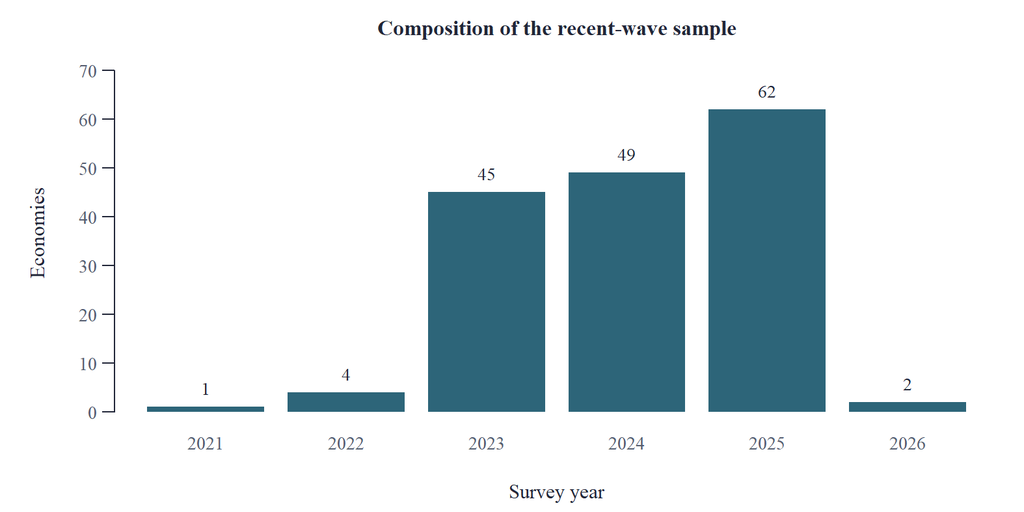

```r
vintages <- table(study$year)
old <- plot_start(margins = c(4, 4.6, 2.2, 1))
bars <- barplot(vintages, col = blue, border = NA, ylim = c(0, max(vintages) * 1.18),
                ylab = "Economies", xlab = "Survey year", main = "Composition of the recent-wave sample")
text(bars, vintages, labels = vintages, pos = 3, col = ink, cex = 0.85)
```

```r
par(old)
```

```r
tab(profiles, "Observable differences between included and excluded groups")
```

Observable differences between included and excluded groups

| Group | N | Credit | First | Last | Median |
| --- | --- | --- | --- | --- | --- |
| Recent | 163 | 36.47 | 2021 | 2026 | 2024 |
| Pre-2021 | 18 | 30.95 | 2009 | 2020 | 2015 |
| QoG origin known | 129 | 36.44 | 2022 | 2026 | 2024 |
| QoG origin missing | 34 | 36.56 | 2021 | 2025 | 2024 |
| English or named civil-code origin | 119 | 36.62 | 2022 | 2026 | 2024 |
| Excluded from English/civil contrast | 44 | 36.06 | 2021 | 2025 | 2024 |

Earlier-wave economies differ in observed credit holding. Legal-code availability produces another kind of exclusion. Similar mean credit between classified and unclassified economies does not imply similar geography, institutional history or exposure. Comparing models with and without the legal-origin dummy on the **same classified sample** helps separate the contribution of the new variable from the shift in sample composition.

## 3.4 Verify the sign and reproduce the pitch

The indicator title refers to independence and impartiality. The current survey construction assigns low scores to agreement and high scores to disagreement. This is why the notebook calls the regressor **court doubt**. To report the slope in terms of court confidence instead, define confidence as `100 - BREADY_DISP3`. With an intercept that reverses the slope and leaves fitted values unchanged. A negative slope for doubt would therefore be consistent with a positive association for confidence. [World Bank indicator descriptions, DISP3](https://www.enterprisesurveys.org/content/dam/enterprisesurveys/documents/methodology/Indicator-Description.pdf)

```r
direction_example <- merge(direction_values, unique(study[c("economy", "name")]),
                           by = "economy", sort = FALSE)
tab(direction_example[c("name", "year", "BREADY_DISP3", "CRIME9", "BREADY_DISP6")],
    "A check on orientation · court doubt and two court-obstacle measures")
```

A check on orientation · court doubt and two court-obstacle measures

| name | year | BREADY_DISP3 | CRIME9 | BREADY_DISP6 |
| --- | --- | --- | --- | --- |
| Germany | 2025 | 1.25 | 2.06 | 5.70 |
| Kuwait | 2025 | 0.00 | 0.00 | 2.06 |
| North Macedonia | 2023 | 71.69 | 19.85 | 27.49 |
| Pakistan | 2022 | 33.17 | 11.04 | 24.08 |

```r
# Rows where the rebuilt value rounds differently at the printed precision.
tab(pitch_differences, "Differences from the pitch's displayed precision", digits = 5)
```

Differences from the pitch’s displayed precision

| indicator | statistic | pitch | rebuilt | rounded | two stage |
| --- | --- | --- | --- | --- | --- |
| BREADY_DISP3 | Mean | 26.4 | 26.34673 | 26.3 | 26.4 |
| CRIME9 | SD | 10.2 | 10.14835 | 10.1 | 10.2 |

The country examples and correlations later in the notebook check plausibility. The coding documentation determines the direction. The pitch reconciliation exposes rounding as well as coverage. The two printed discrepancies can be reproduced by rounding first to two decimal places and then to the displayed precision. The original calculation is unavailable.

# 4 Explore before fitting

## 4.1 Distributions, units and unusual economies

Use the count, center, dispersion and range together. The mean describes the average economy. The median reflects the middle economy and is less affected by extreme values. Quartiles show how much of an apparent range is populated. Check the tails before fitting because an unusual regressor can exert leverage even when its credit share looks ordinary.

```r
# Summaries reflect the economy-level sample; the SD is the ordinary sample SD.
distribution <- function(x) {
  x <- x[is.finite(x)]
  quartiles <- unname(quantile(x, c(0.25, 0.75)))
  c(N = length(x), Mean = mean(x), SD = sd(x), Min = min(x), Q1 = quartiles[1],
    Median = median(x), Q3 = quartiles[2], Max = max(x))
}
descriptive <- t(vapply(study[c(pitch_codes, "log_workers")], distribution, numeric(8)))
tab(data.frame(Measure = term_labels(rownames(descriptive)), descriptive, row.names = NULL),
    "Distribution of the same-wave measures")
```

Distribution of the same-wave measures

| Measure | N | Mean | SD | Min | Q1 | Median | Q3 | Max |
| --- | --- | --- | --- | --- | --- | --- | --- | --- |
| Credit holding | 163 | 36.47 | 19.64 | 2.11 | 20.68 | 36.05 | 50.18 | 88.52 |
| Court doubt | 163 | 26.35 | 16.44 | 0.00 | 14.68 | 24.50 | 34.18 | 71.69 |
| Courts an obstacle | 163 | 10.08 | 10.15 | 0.00 | 2.06 | 6.84 | 15.41 | 43.37 |
| Dispute resolution use | 163 | 54.00 | 20.07 | 0.00 | 42.08 | 55.69 | 66.66 | 100.00 |
| Bribery incidence | 163 | 10.79 | 10.84 | 0.00 | 2.49 | 7.16 | 16.25 | 50.47 |
| Collateral required | 163 | 66.82 | 22.51 | 16.91 | 48.89 | 70.12 | 87.38 | 100.00 |
| No loan needed | 163 | 51.43 | 17.70 | 5.57 | 38.83 | 51.73 | 65.87 | 89.74 |
| Workers per firm | 163 | 39.03 | 30.81 | 9.66 | 25.13 | 33.12 | 42.58 | 318.47 |
| Commercial disputes | 163 | 14.04 | 8.06 | 0.52 | 8.96 | 13.28 | 18.67 | 46.93 |
| Log workers | 163 | 3.51 | 0.52 | 2.27 | 3.22 | 3.50 | 3.75 | 5.76 |

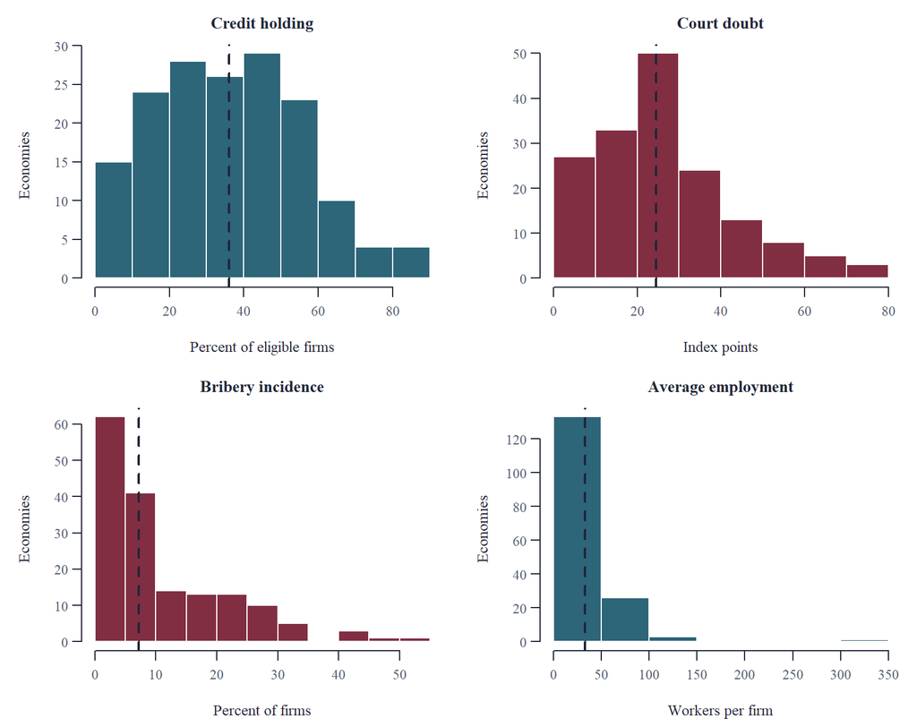

```r
old <- plot_start(c(2, 2))
draw_hist <- function(values, label, measure, color, breaks = "Sturges") {
  hist(values, breaks = breaks, col = color, border = "white",
       main = label, xlab = measure, ylab = "Economies")
  abline(v = median(values), col = ink, lwd = 2, lty = 2)
}
draw_hist(study$FIN14, "Credit holding", "Percent of eligible firms", blue)
draw_hist(study$BREADY_DISP3, "Court doubt", "Index points", burgundy)
draw_hist(study$GRAFT3, "Bribery incidence", "Percent of firms", burgundy)
draw_hist(study$WK21, "Average employment", "Workers per firm", blue)
```

```r
par(old)
```

Dashed lines mark the sample medians. Average employment has a long right tail. A natural log compresses the upper end and lets us ask about proportional size differences. For example, doubling average employment is an increase of $\log(2)$ on the transformed scale. Using logs is a modeling choice about the mean relationship. A later refit in levels tests whether this choice drives the institution estimates.

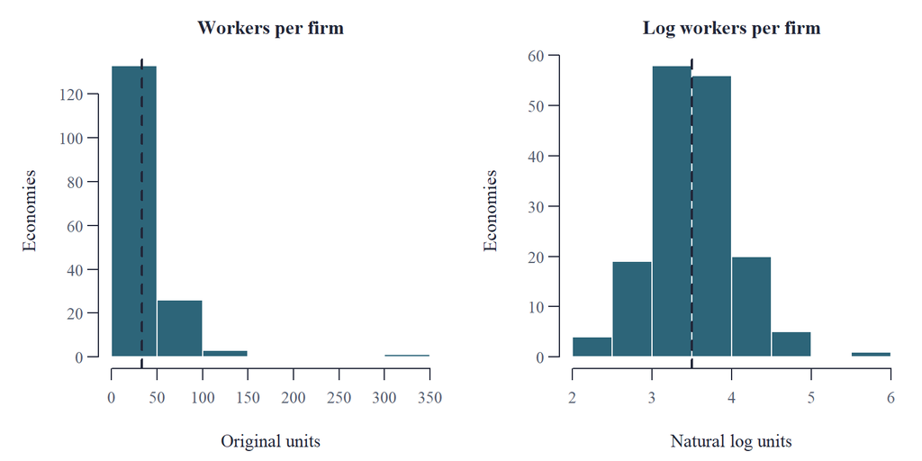

```r
old <- plot_start(c(1, 2))
draw_hist(study$WK21, "Workers per firm", "Original units", blue)
draw_hist(study$log_workers, "Log workers per firm", "Natural log units", blue)
```

```r
par(old)
```

```r
tab(workers_form, "Workforce skewness before and after the log transformation")
```

Workforce skewness before and after the log transformation

| Scale | Skewness | Median | Max |
| --- | --- | --- | --- |
| Workers | 5.35 | 33.12 | 318.47 |
| Log workers | 0.64 | 3.50 | 5.76 |

## 4.2 Look for co-movement

Pearson correlation summarizes linear co-movement. Spearman correlation compares ranks and reduces sensitivity to the distance of an extreme data point from the rest. Both here are bivariate. Neither controls for the other institution measure or firm size. A change in the estimate after adding covariates is possible even if the raw trend appears stable.

```r
# Compare like with like by using all four variables on the complete core sample.
eda_codes <- c("FIN14", "BREADY_DISP3", "GRAFT3", "log_workers")
eda <- study[eda_codes]
names(eda) <- term_labels(eda_codes)
r_pearson <- cor(eda)
r_spearman <- cor(eda, method = "spearman")
tab(data.frame(Measure = names(eda)[-1], Pearson = unname(r_pearson[-1, 1]),
               Spearman = unname(r_spearman[-1, 1])),
    "Raw correlations with credit holding", digits = 3)
```

Raw correlations with credit holding

| Measure | Pearson | Spearman |
| --- | --- | --- |
| Court doubt | -0.050 | -0.074 |
| Bribery incidence | -0.400 | -0.439 |
| Log workers | 0.268 | 0.265 |

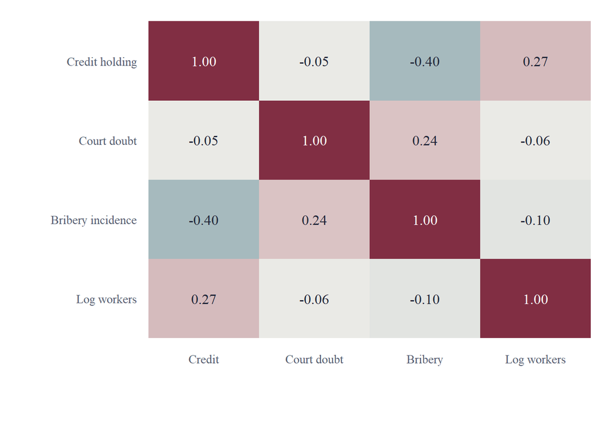

```r
# Use the same fixed color scale across all cells, including the diagonal.
old <- plot_start(margins = c(5, 9, 1.3, 1.2))
k <- nrow(r_pearson)
palette <- colorRampPalette(c("#2D6579", "#F7F3ED", "#812E43"))(101)
image(seq_len(k), seq_len(k), t(r_pearson[k:1, ]), col = palette,
      zlim = c(-1, 1), axes = FALSE, xlab = "", ylab = "")
axis(1, at = seq_len(k), labels = c("Credit", "Court doubt", "Bribery", "Log workers"), tick = FALSE)
axis(2, at = seq_len(k), labels = rev(rownames(r_pearson)), tick = FALSE)
for (i in seq_len(k)) for (j in seq_len(k)) {
  val <- r_pearson[k + 1L - j, i]
  text(i, j, f2(val), col = if (abs(val) > 0.65) "white" else ink, cex = 1.04)
}
```

```r
par(old)
```

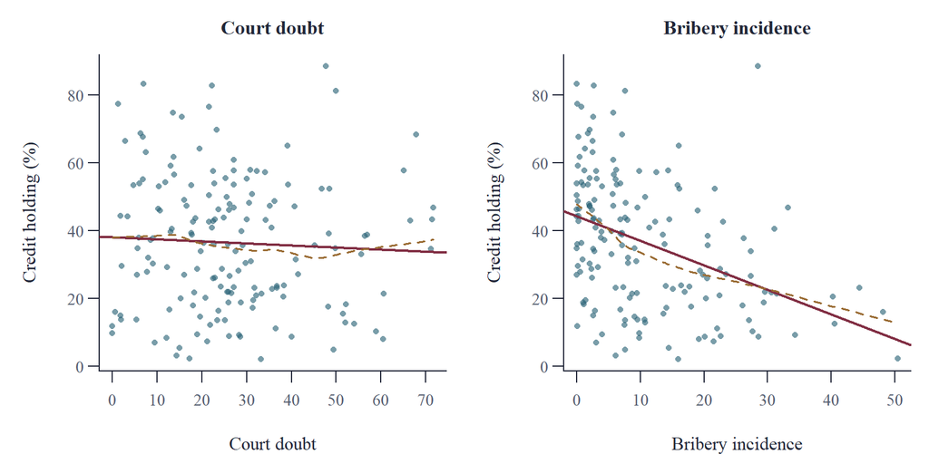

```r
old <- plot_start(c(1, 2))
for (feature in c("BREADY_DISP3", "GRAFT3")) {
  x <- study[[feature]]
  y <- study$FIN14
  plot(x, y, pch = 16, cex = 0.7, col = adjustcolor(blue, alpha.f = 0.64),
       xlab = term_labels(feature), ylab = "Credit holding (%)",
       main = term_labels(feature))
  abline(lm(y ~ x), col = burgundy, lwd = 2.1)
  lines(lowess(x, y), col = gold, lwd = 1.7, lty = 2)
}
```

```r
par(old)
```

The straight lines are separate raw OLS fits. The dashed curves are local smoothers that can reveal curvature or sparse tails. They are exploratory visual summaries. A nearly flat court line leads to a question about weak fit, uncertainty and whether comparison on the observed covariates changes the picture.

## 4.3 Compare regional profiles

Each row below describes the average **economy** in a region. The group means are useful for seeing why a pooled association can differ from a within-region comparison. Regions can differ simultaneously in credit, firm composition and institutional exposure. Some groups contain few economies, and the legal-code coverage also varies. Treat a regional mean as an observed group description.

```r
# Preserve the economy as the unit when calculating region summaries.
regional_means <- aggregate(study[c("FIN14", "BREADY_DISP3", "GRAFT3")],
                            by = list(Region = study$region), FUN = mean)
region_ref <- unique(regions[c("region", "region_label")])
counts <- region_counts[match(regional_means$Region, region_counts$Region), ]
regional_means$Region <- region_ref$region_label[match(regional_means$Region, region_ref$region)]
regional_means$N <- counts$Recent
regional_means[["QoG origin known"]] <- counts$Recent - counts$QoG_missing
names(regional_means)[2:4] <- c("Credit holding", "Court doubt", "Bribery incidence")
tab(regional_means[c("Region", "N", "Credit holding", "Court doubt",
                     "Bribery incidence", "QoG origin known")],
    "Regional averages and legal-origin coverage in the recent sample")
```

Regional averages and legal-origin coverage in the recent sample

| Region | N | Credit holding | Court doubt | Bribery incidence | QoG origin known |
| --- | --- | --- | --- | --- | --- |
| East Asia & Pacific | 25 | 35.73 | 17.69 | 12.16 | 21 |
| Europe & Central Asia | 45 | 45.82 | 25.01 | 4.34 | 23 |
| Latin America & Caribbean | 24 | 51.37 | 32.21 | 8.11 | 21 |
| Middle East, North Africa, Afghanistan & Pakistan | 16 | 24.76 | 20.18 | 13.71 | 15 |
| North America | 2 | 45.14 | 16.74 | 4.31 | 2 |
| South Asia | 6 | 39.74 | 27.98 | 11.17 | 6 |
| Sub-Saharan Africa | 45 | 22.92 | 31.77 | 17.12 | 41 |

# 5 Fit the first regression

## 5.1 From a population relationship to sample estimates

Let $Y_i$ be FIN14 in percentage points and $D_i$ be court doubt in index points. A linear **population regression function** specifies a conditional mean

$$E[Y_i \mid D_i] = \alpha + \beta D_i.$$

The stochastic equation is $Y_i=\alpha+\beta D_i+u_i$. The disturbance $u_i$ collects differences in economy conditions left out of the equation, survey measurement error and deviations from the conditional mean. Individual economies can lie above or below the line. The residual $\hat u_i=Y_i-\hat Y_i$ is the deviation from the **fitted sample line**. It is observable after fitting. The population disturbance is unobserved.

Classical linear regression assumptions and where they matter

| Assumption | Why we need it | What to check here |
| --- | --- | --- |
| Linear in the coefficients | Defines the OLS form. Transformations such as log employment can enter as regressors. | Scatterplots, residual plots, a fitted-powers test and a bounded model. |
| Variation and full column rank | We need unique slope estimates. Exact collinearity prevents identifying separate slopes. | Check the design rank. Inspect correlations and VIF for near redundancy. |
| Zero conditional mean, $E[u_i\mid X_i]=0$ | With an appropriate sampling model, the equation estimates the specified conditional mean without systematic omitted shifts. | National income and banking conditions are plausible omissions. No residual test can establish this assumption. |
| Sampling and generalization | A population interpretation requires a sampling or outcome model for the observed economies. | The archive contains available survey waves. Its coverage does not constitute a random draw of all economies or years. |
| Independent economy errors and constant conditional variance | Support the classical covariance formula and efficiency result under the other assumptions. | Use HC3 for uneven variance. Probe regional dependence separately because HC3 allows uneven variances across independent observations. |
| Normal errors conditional on the design | With the other classical conditions, yields exact finite-sample t and F reference distributions. | The HC3 tests use approximate references. We make no claim of exact normality in these data. |

Under suitable sampling and finite moments, OLS can describe the best linear projection even when the conditional mean curves. The interpretation remains an economy-level association. Also, least squares with an intercept constrains the fitted residuals to sum to zero and to be orthogonal to included regressors. Those algebraic properties supply no evidence about whether population errors are independent of the regressors.

## 5.2 Compute OLS by hand and with R

The fitted coefficients minimize $\sum_i (Y_i-\alpha-\beta D_i)^2$. In simple regression the slope is the sample covariance of $Y$ with $D$ divided by the sample variance of $D$. The intercept places the line through the sample means.

$$\hat\beta=\frac{\sum_i (D_i-\bar{D})(Y_i-\bar{Y})}{\sum_i (D_i-\bar{D})^2},
\qquad
\hat\alpha=\bar{Y}-\hat\beta\bar{D}.$$

```r
# Compute the estimates directly from the centered cross-products.
d <- study$BREADY_DISP3
y <- study$FIN14
b <- sum((d - mean(d)) * (y - mean(y))) / sum((d - mean(d))^2)
a <- mean(y) - b * mean(d)

# Fit the same sample with R and verify agreement with the production model.
simple_fit <- lm(FIN14 ~ BREADY_DISP3, data = study, na.action = na.fail)
stopifnot(isTRUE(all.equal(c(a, b), unname(coef(simple_fit)))),
          isTRUE(all.equal(coef(simple_fit), coef(models$Simple))))
tab(data.frame(Term = c("Intercept", "Court doubt"),
               Manual = c(a, b), R = unname(coef(simple_fit))),
    "Verifying the two simple-regression coefficients", digits = 4)
```

Verifying the two simple-regression coefficients

| Term | Manual | R |
| --- | --- | --- |
| Intercept | 38.0465 | 38.0465 |
| Court doubt | -0.0599 | -0.0599 |

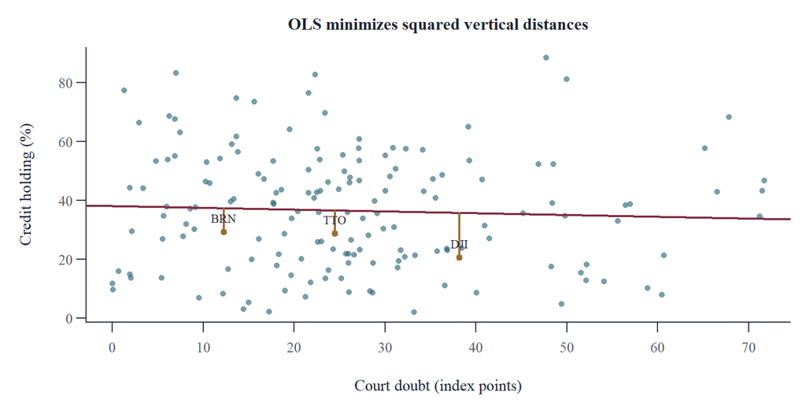

```r
old <- plot_start()
plot(d, y, pch = 16, col = adjustcolor(blue, alpha.f = 0.64), cex = 0.75,
     xlab = "Court doubt (index points)", ylab = "Credit holding (%)",
     main = "OLS minimizes squared vertical distances")
abline(simple_fit, col = burgundy, lwd = 2.45)
# Label three widely spaced observations to illustrate signed residuals.
i <- order(d)[round(quantile(seq_along(d), c(0.2, 0.5, 0.8)))]
segments(d[i], fitted(simple_fit)[i], d[i], y[i], col = gold, lwd = 2)
points(d[i], y[i], pch = 19, col = gold, cex = 0.85)
text(d[i], y[i], study$economy[i], pos = 3, cex = 0.75, col = ink)
```

```r
par(old)
```

The fitted slope is **-0.060 percentage points per index point**. A ten-point difference in doubt corresponds to **-0.60 points** of fitted credit holding. The intercept is the fitted share at zero doubt, the index’s agreement endpoint. The slope is an average linear comparison over the observed range.

## 5.3 Read $R^2$ and adjusted $R^2$

The total sum of squares is the variation around the outcome mean, $TSS=\sum_i (Y_i-\bar Y)^2$. OLS with an intercept decomposes it into explained and residual sums of squares. $R^2=1-RSS/TSS$ reports the fraction accounted for by the fitted line in this sample. Adding regressors on the same rows can only lower $RSS$. Adjusted $R^2$ compares residual and total *mean* squares, using $n-p-1$ and $n-1$ degrees of freedom, respectively, with $p$ slopes.

```r
# Compute the two fit measures explicitly and check summary.lm.
tss <- sum((y - mean(y))^2)
rss <- deviance(simple_fit)
manual_r2 <- 1 - rss / tss
manual_adj <- 1 - (rss / df.residual(simple_fit)) / (tss / (length(y) - 1))
stopifnot(isTRUE(all.equal(manual_r2, summary(simple_fit)$r.squared)),
          isTRUE(all.equal(manual_adj, summary(simple_fit)$adj.r.squared)))
tab(data.frame(Total = tss, Explained = tss - rss, Residual = rss,
               R2 = manual_r2, Adjusted_R2 = manual_adj),
    "Simple-model variation and fit", digits = 4)
```

Simple-model variation and fit

| Total | Explained | Residual | R² | Adjusted R2 |
| --- | --- | --- | --- | --- |
| 62478.14 | 157.2473 | 62320.89 | 0.0025 | -0.0037 |

Court doubt alone accounts for about **0.25%** of the between-economy credit variation. The slightly negative adjusted statistic reflects the degrees-of-freedom penalty on a very small fit gain. Both measures describe in-sample fit and cannot establish a causal model.

# 6 Extend the model

## 6.1 What does “holding the other variables fixed” mean?

Add bribery incidence $B_i$ and the natural log of average employment $W_i$ to the same economies. $W_i$ is measured in workers before transformation.

$$Y_i=\alpha+\beta_D D_i+\beta_B B_i+\theta\log(W_i)+u_i.$$

$\beta_D$ is a one-point court-doubt comparison at the same reported bribery and average employment. $\beta_B$ holds court doubt and log employment fixed. When average employment doubles, $\log(W)$ changes by $\log(2)$ and the fitted share changes by $\theta\log(2)$. The firm-size control describes a difference across economies with different average employment. The unit still cannot identify an individual firm’s credit probability.

```r
# Keeping the same row set separates changes in the specification from attrition.
core_fit <- lm(FIN14 ~ BREADY_DISP3 + GRAFT3 + log_workers, data = study,
               na.action = na.fail)
stopifnot(identical(rownames(model.frame(simple_fit)), rownames(model.frame(core_fit))),
          isTRUE(all.equal(coef(core_fit), coef(core))))
fit_overview <- model_fit[c("Model", "N", "Slopes", "R2", "Adjusted_R2")]
fit_overview[["Residual df"]] <- fit_overview$N - fit_overview$Slopes - 1
tab(fit_overview, "Specification ladder · read fit changes within the same sample", digits = 3)
```

Specification ladder · read fit changes within the same sample

| Model | N | Slopes | R² | Adjusted R2 | Residual df |
| --- | --- | --- | --- | --- | --- |
| Simple | 163 | 1 | 0.003 | -0.004 | 161 |
| Core | 163 | 3 | 0.215 | 0.200 | 159 |
| Core on QoG sample | 129 | 3 | 0.217 | 0.198 | 125 |
| QoG origin | 129 | 4 | 0.227 | 0.202 | 124 |
| English vs civil codes | 119 | 4 | 0.235 | 0.208 | 114 |
| Full specification on QoG sample | 129 | 9 | 0.386 | 0.340 | 119 |

On the same **163 economies**, the core accounts for 21.5% of the observed variation, compared with 0.25% for the simple line. Its adjusted share is 20.0%. The gains show that the added variables account for more variation in the sample even after the fit penalty. The estimates still need tests and sensitivity checks to support an institutional interpretation.

### 6.1.1 See the partial slope directly

The Frisch–Waugh–Lovell result gives a visual interpretation. First remove the fitted contribution of bribery and log employment from both credit and court doubt. Then regress residual credit on residual doubt. Its slope equals the court slope in the full core model. This exercise shows how the conditional comparison is constructed.

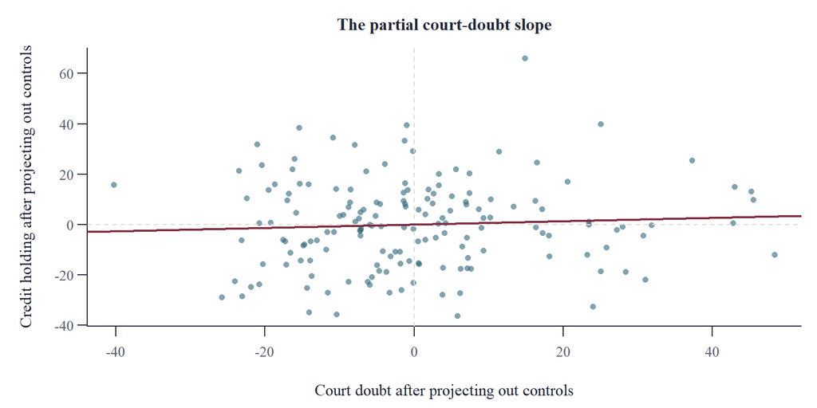

```r
# Residualize both variables against exactly the same controls and sample.
remaining_credit <- residuals(lm(FIN14 ~ GRAFT3 + log_workers, data = study))
remaining_doubt <- residuals(lm(BREADY_DISP3 ~ GRAFT3 + log_workers, data = study))
partial_line <- lm(remaining_credit ~ remaining_doubt)
stopifnot(isTRUE(all.equal(unname(coef(partial_line)[2]), unname(coef(core_fit)["BREADY_DISP3"]))))

old <- plot_start()
plot(remaining_doubt, remaining_credit, pch = 16, cex = 0.75,
     col = adjustcolor(blue, alpha.f = 0.6), xlab = "Court doubt after projecting out controls",
     ylab = "Credit holding after projecting out controls", main = "The partial court-doubt slope")
abline(h = 0, v = 0, lty = 2, col = grid_col)
abline(partial_line, col = burgundy, lwd = 2.2)
```

```r
par(old)
```

The core court slope is **0.067**. Its direction differs from the simple slope. The point estimate changes because the residualized comparison uses a different component of the same court measure. The change alone cannot establish which specification removes omitted-variable bias. Controls can alter a coefficient because they account for confounding, because they condition on a mechanism, or because of sampling noise. Uncertainty matters when both estimates are small.

## 6.2 Add a legal-origin dummy carefully

The archived QoG series `lp_legor` classifies the origin of company law or the commercial code. Use $L_i=1$ for documented English common law, $L_i=0$ for documented comparison origins and leave unavailable values missing. The primary pooled comparator includes the Socialist category. The stricter civil-code comparison retains only English, French, German and Scandinavian origins. The coding of mixed systems and the pitch’s imputation rule are sensitivity questions. [QoG legal-origin definition](https://datafinder.qog.gu.se/variable/lp_legor)

```r
# These counts refer to the archived codes on the recent-wave sample.
tab(origin_counts, "Legal-origin categories before defining the comparison group", digits = 0)
```

Legal-origin categories before defining the comparison group

| Origin | N |
| --- | --- |
| English | 46 |
| French | 63 |
| Socialist | 10 |
| German | 5 |
| Scandinavian | 5 |
| Unknown | 34 |

```r
# A matched record with a blank classification differs from an unmatched economy code.
tab(data.frame(Status = c("QoG record found, origin blank", "No matching QoG economy code"),
               N = c(sum(origin_audit$origin_row), sum(!origin_audit$origin_row))),
    "Why recent-wave legal codes are missing", digits = 0)
```

Why recent-wave legal codes are missing

| Status | N |
| --- | --- |
| QoG record found, origin blank | 31 |
| No matching QoG economy code | 3 |

With a dummy and common slopes, changing $L$ from zero to one shifts the fitted intercept by $\delta$. To see this in R, predict twice at the same values of the other covariates. These are fitted profiles for comparing origins. They do not describe a real economy changing its legal heritage.

```r
# Fix the same covariates twice and vary only the legal-origin indicator.
reference <- data.frame(
  BREADY_DISP3 = mean(known$BREADY_DISP3),
  GRAFT3 = mean(known$GRAFT3),
  log_workers = mean(known$log_workers),
  common = c(0, 1)
)
profile_fits <- predict(origin_fit, newdata = reference)
stopifnot(isTRUE(all.equal(unname(diff(profile_fits)), unname(coef(origin_fit)["common"]))))
tab(data.frame(Origin = c("Other documented origin", "English common law"),
               Adjusted_credit = unname(profile_fits)),
    "Fitted credit at the same court, bribery and employment values")
```

Fitted credit at the same court, bribery and employment values

| Origin | Adjusted credit |
| --- | --- |
| Other documented origin | 38.03 |
| English common law | 33.58 |

```r
# Use the HC3 intervals from the anchored origin comparisons.
origin_rows <- origin_sensitivity[1:2, ]
tab(origin_rows, "Conditional differences by English common-law origin", digits = 3)
```

Conditional differences by English common-law origin

| Model | N | Estimate | Lower | Upper | p |
| --- | --- | --- | --- | --- | --- |
| QoG, all observed origins | 129 | -4.449 | -11.337 | 2.439 | 0.204 |
| English vs civil codes | 119 | -4.685 | -11.802 | 2.432 | 0.195 |

Both intervals span zero and also allow sizable differences. The full pitch set is informative as a specification check. Use of dispute resolution is measured in the group that reports disputes. Collateral is measured among borrowers, and lack of need is a reported reason for skipping an application. Including these measures can condition on selection or a lending mechanism. A higher adjusted $R^2$ for the pitch model on the same QoG rows can be real as a gain in fit while leaving those concerns intact.

# 7 Test the claims

## 7.1 Individual tests and economic magnitudes

For court doubt, bribery and the dummy, the two-sided null is $H_0:\beta_j=0$ and the alternative is $H_1:\beta_j\ne 0$. Costly recovery and public transactions motivate negative expectations for doubt and bribery. The legal-origin hypothesis predicts a positive common-law comparison. Inference uses both tails. The t statistic is $\hat\beta_j/SE(\hat\beta_j)$ under the zero null. The p-value uses the reference probability of observing a statistic at least as far from zero as ours, conditional on the null and the inference assumptions. The 95% interval adds and subtracts a critical multiple of the standard error. If it spans zero, the corresponding two-sided test does not reject at 5%. It can still contain policy-relevant differences.

```r
# A scaled contrast rescales the slope AND its standard error and interval.
# Exclude the standardized comparisons here so each row has business units.
teaching_effects <- core_effects[1:3, c("Comparison", "Estimate", "SE", "t", "df", "p", "Lower", "Upper")]
tab(teaching_effects, "Core t tests in interpretable credit-share units · HC3", digits = 3)
```

Core t tests in interpretable credit-share units · HC3

| Comparison | Estimate | SE | t | df | p | Lower | Upper |
| --- | --- | --- | --- | --- | --- | --- | --- |
| Court doubt, 10 points | 0.670 | 0.881 | 0.760 | 159 | 0.448524 | -1.071 | 2.411 |
| Bribery incidence, 10 points | -7.056 | 1.176 | -6.000 | 159 | 1.29e-08 | -9.379 | -4.733 |
| Average employment, doubled | 6.026 | 1.582 | 3.808 | 159 | 0.000199 | 2.901 | 9.151 |

In the core model a ten-point rise in bribery is associated with **7.06 points lower** credit holding. The interval excludes zero. For court doubt the interval includes zero and both signs. For a business interpretation of any coefficient, report the unit, what was held fixed and how large the interval is. A small p-value alone cannot rank two predictors or show that a reform would pay off.

## 7.2 F tests answer a different question

The classical test compares a restricted model with a less restricted model on identical rows. For example, the simple model imposes zero coefficients on bribery and log employment. The extra-sum-of-squares F statistic divides the reduction in residual variation per restriction by the full model’s residual mean square. The robust Wald version instead evaluates the restrictions with an HC3 covariance matrix. The study uses the number of restrictions and the full model’s residual degrees of freedom as approximate F references for the robust test.

```r
# H0: bribery and log employment both have zero slopes, given court doubt.
nested <- anova(simple_fit, core_fit)
tab(data.frame(Restrictions = nested$Df[2], F = nested$F[2], p = nested[["Pr(>F)"]][2]),
    "Classical nested test · add bribery and size to the simple model", digits = 3)
```

Classical nested test · add bribery and size to the simple model

| Restrictions | F | p |
| --- | --- | --- |
| 2 | 21.54 | 5.27e-09 |

```r
# Overall H0: all core slopes are zero.
# Institutions H0: the court and bribery slopes are zero, conditional on size.
test_rows <- subset(joint_results, Model == "Core", select = -Model)
tab(test_rows, "Overall and institutional joint tests on the core sample", digits = 3)
```

Overall and institutional joint tests on the core sample

| Test | F | df1 | df2 | p |
| --- | --- | --- | --- | --- |
| Overall classical | 14.530 | 3 | 159 | 2.07e-08 |
| Overall HC3 | 18.424 | 3 | 159 | 2.62e-10 |
| Institutional HC3 | 18.170 | 2 | 159 | 7.82e-08 |

The institutional F statistic can be significant because one institutional measure carries most of the information. It provides no test that both slopes are individually different from zero. With a single restriction and the same covariance, $F=t^2$, so the simple-model slope provides a useful consistency check.

```r
# Scale the effect and its interval to 10 court-doubt points.
simple_t <- linear_test(simple_fit, c(BREADY_DISP3 = 10))
single_f <- block_test(simple_fit, "BREADY_DISP3")
stopifnot(isTRUE(all.equal(unname(simple_t["t"]^2), unname(single_f["F"]))))
tab(data.frame(Estimate_pp = unname(simple_t["Estimate"]),
               HC3_interval = interval(simple_t["Lower"], simple_t["Upper"]),
               t = unname(simple_t["t"]), F = unname(single_f["F"]), p = unname(single_f["p"])),
    "Simple-model court comparison per ten points · one-restriction F and t", digits = 3)
```

Simple-model court comparison per ten points · one-restriction F and t

| Estimate pp | HC3 interval | t | F | p |
| --- | --- | --- | --- | --- |
| -0.599 | [-2.59, 1.39] | -0.595 | 0.355 | 0.552 |

## 7.3 Do the institutional associations differ?

An index point of court doubt and a percentage point of bribery incidence are distinct units. Use one sample standard deviation of each adverse exposure to compare their signed slopes. Denote their SDs by $s_D$ and $s_B$. The signed difference $\Delta=s_D\beta_D-s_B\beta_B$ is a single linear contrast. Test $H_0:\Delta=0$ against $H_1:\Delta\ne0$. Its variance uses the two slope variances **and their covariance**.

$$\operatorname{Var}(\hat\Delta)=s_D^2\operatorname{Var}(\hat\beta_D)
+s_B^2\operatorname{Var}(\hat\beta_B)
-2s_Ds_B\operatorname{Cov}(\hat\beta_D,\hat\beta_B).$$

```r
# Hold the sample SDs fixed and apply the joint HC3 covariance.
weights <- c(BREADY_DISP3 = sd(study$BREADY_DISP3), GRAFT3 = -sd(study$GRAFT3))
delta <- linear_test(core_fit, weights)
standardized <- core_effects[4:6, c("Comparison", "Estimate", "Lower", "Upper", "p")]
stopifnot(isTRUE(all.equal(unname(delta["Estimate"]), standardized$Estimate[3])))
tab(standardized, "Adverse one-SD comparisons and the signed difference", digits = 3)
```

Adverse one-SD comparisons and the signed difference

| Comparison | Estimate | Lower | Upper | p |
| --- | --- | --- | --- | --- |
| Court doubt, one SD | 1.101 | -1.761 | 3.963 | 0.449 |
| Bribery incidence, one SD | -7.651 | -10.170 | -5.133 | 1.29e-08 |
| Court minus bribery, one SD each | 8.752 | 4.885 | 12.619 | 1.48e-05 |

A difference between two signed slopes is a separate question from a difference in their absolute magnitudes. For the latter, an exploratory test asks whether $s_B\beta_B < -|s_D\beta_D|$. This requires the court-minus-bribery contrast to be positive **and** the court-plus-bribery contrast to be negative. The larger one-sided p-value is 0.000368 in the core sample. Partial $R^2$ helps describe how much residual variation each predictor accounts for when added to the other terms.

```r
tab(partial_fit, "Incremental fit from adding each predictor to the other core terms", digits = 4)
```

Incremental fit from adding each predictor to the other core terms

| Term | SD | Partial R2 |
| --- | --- | --- |
| Court doubt | 16.4420 | 0.0038 |
| Bribery incidence | 10.8433 | 0.1534 |

**What the core model says**

Bribery has the larger adverse standardized association in this specification. The court coefficient remains imprecise. The comparison is conditional on the particular measures, sample and covariates. The next checks ask how credible that description is under different assumptions.

# 8 Diagnose the model

## 8.1 Unequal error variance and the HC3 correction

Some survey aggregates are noisier than others. Credit differences across economies of similar observed characteristics can also have different spreads. The **studentized Breusch–Pagan test** asks whether the conditional error variance is constant versus related to the regressors in its auxiliary equation. Regress squared OLS residuals on the original covariates and compare $nR_{\mathrm{aux}}^2$ with a chi-square reference with one degree of freedom per slope. This version uses a studentized statistic for the variance test. [Koenker, *Journal of Econometrics*](https://doi.org/10.1016/0304-4076%2881%2990062-2)

```r
# Calculate the core statistic by hand, then compare the model sequence.
auxiliary <- lm(I(residuals(core_fit)^2) ~ BREADY_DISP3 + GRAFT3 + log_workers,
                data = study)
bp_manual <- nobs(core_fit) * summary(auxiliary)$r.squared
stopifnot(isTRUE(all.equal(bp_manual, bp$Chi_squared[bp$Model == "Core"])))
tab(bp, "Studentized Breusch–Pagan · null of constant conditional error variance", digits = 4)
```

Studentized Breusch–Pagan · null of constant conditional error variance

| Model | Chi squared | df | p |
| --- | --- | --- | --- |
| Core | 0.7489 | 3 | 0.86164 |
| QoG origin | 0.8556 | 4 | 0.93085 |
| Full pitch terms | 16.8183 | 9 | 0.05164 |

The core test supplies little evidence of the variance relationship it looks for. The full pitch model is closer to a conventional threshold. Neither test proves homoskedasticity. Under conditional mean independence, unequal variance alone leaves the OLS coefficients consistent but can make classical standard errors unreliable and OLS inefficient relative to a correctly weighted estimator. The archive lacks comparable observation-level variances for defensible precision weights.

HC3 uses the squared leverage-adjusted residuals, $\hat u_i^2/(1-h_{ii})^2$, to estimate the covariance matrix. This preserves the OLS coefficients and re-estimates their uncertainty. A high-leverage row gets a larger adjustment for the residual shrinkage associated with fitting it. [MacKinnon and White, *Journal of Econometrics*](https://doi.org/10.1016/0304-4076%2885%2990158-7)

```r
# The matrix computation makes clear where leverage enters.
X <- model.matrix(core_fit)
bread <- summary(core_fit)$cov.unscaled
scores <- X * (residuals(core_fit) / (1 - hatvalues(core_fit)))
V3 <- bread %*% crossprod(scores) %*% bread
stopifnot(isTRUE(all.equal(V3, hc3(core_fit))))

display_se <- subset(se_comparison, Model == "Core", select = -Model)
display_se$Term <- term_labels(display_se$Term)
tab(display_se, "Classical and HC3 uncertainty for the same coefficients", digits = 4)
```

Classical and HC3 uncertainty for the same coefficients

| Term | Estimate | Classical SE | HC3_SE | Classical p | HC3 p |
| --- | --- | --- | --- | --- | --- |
| Court doubt | 0.0670 | 0.0864 | 0.0881 | 0.4395 | 0.4485 |
| Bribery incidence | -0.7056 | 0.1315 | 0.1176 | 2.79e-07 | 1.288e-08 |

A robust SE can be smaller or larger than a classical SE. Here HC3 changes the standard errors and test statistics while preserving the qualitative findings for the institutional slopes. The correction does not address omitted variables or correlations among economies.

## 8.2 Durbin–Watson and residual order

Durbin–Watson compares squared differences between adjacent residuals with the residual sum of squares.

$$DW=\frac{\sum_{i=2}^n(\hat u_i-\hat u_{i-1})^2}{\sum_{i=1}^n\hat u_i^2}.$$

The classical diagnostic asks whether the errors exhibit first-order dependence along a meaningful sequence. Here the null reference simulates independent normal errors with constant variance, holding the design fixed. In a cross-section, changing the order changes which residuals count as adjacent, even while the coefficients and residuals attached to individual economies stay the same.

```r
# Reorder the SAME residuals, rather than refitting the core equation.
e <- residuals(core_fit)
by_code <- order(study$economy, method = "radix")
by_year <- order(study$year, study$economy, method = "radix")
by_region <- order(study$region, study$economy, method = "radix")
direct_dw <- vapply(list(by_code, by_year, by_region), function(i) dw_stat(e[i]), numeric(1))
dw_core <- subset(dw, Model == "Core", select = -Model)
stopifnot(isTRUE(all.equal(direct_dw, dw_core$DW)))
tab(dw_core, "Core Durbin–Watson values · same fit, three orderings", digits = 3)
```

Core Durbin–Watson values · same fit, three orderings

| Order | DW | p |
| --- | --- | --- |
| Economy code | 1.916 | 0.5860 |
| Survey year, then code | 1.643 | 0.0248 |
| Region, then code | 1.711 | 0.0648 |

Ordering by survey year groups distinct economies of similar vintage together. It gives a smaller nominal p-value here. This observation motivates a cohort sensitivity and supplies no time-series interpretation for adjacent economy labels. Regional shocks are a more plausible dependence channel. Cohort and region controls can absorb shared differences in levels. Region-clustered uncertainty addresses a different issue by allowing error dependence within a region. The study has only a few uneven groups, so the notebook shows those standard errors as a sensitivity and keeps the reference tests conditional on economy independence.

```r
region_display <- subset(region_se, Model == "Core", select = -Model)
region_display$Term <- term_labels(region_display$Term)
tab(region_display, "HC3 versus region-clustered CR1 standard errors", digits = 3)
```

HC3 versus region-clustered CR1 standard errors

| Term | HC3 | Region CR1 | Groups | Min size | Max size |
| --- | --- | --- | --- | --- | --- |
| Court doubt | 0.088 | 0.128 | 7 | 2 | 45 |
| Bribery incidence | 0.118 | 0.172 | 7 | 2 | 45 |

## 8.3 Collinearity, functional form and influence

For a regressor $X_j$, its variance inflation factor is $1/(1-R_j^2)$, where $R_j^2$ comes from regressing it on the other predictors. VIF measures how redundant the regressor is within the design. A large value can make its partial coefficient unstable and imprecise. Pairwise correlations help identify overlaps driven by particular measures, but multiple predictors can be jointly redundant without a striking pairwise correlation.

```r
# Rebuild the court VIF in the core using its auxiliary regression.
doubt_aux <- lm(BREADY_DISP3 ~ GRAFT3 + log_workers, data = study)
manual_vif <- 1 / (1 - summary(doubt_aux)$r.squared)
stopifnot(isTRUE(all.equal(manual_vif, unname(model_vif(core_fit)["BREADY_DISP3"]))))

vif_check <- vifs[vifs$Model %in% c("Core", "Full pitch terms"), ]
vif_check$Term <- term_labels(vif_check$Term)
tab(vif_check, "Variance inflation across the core and full pitch specifications")
```

Variance inflation across the core and full pitch specifications

| Model | Term | VIF |
| --- | --- | --- |
| Core | Court doubt | 1.06 |
| Core | Bribery incidence | 1.07 |
| Core | Log workers | 1.01 |
| Full pitch terms | Court doubt | 1.50 |
| Full pitch terms | Bribery incidence | 1.40 |
| Full pitch terms | Log workers | 1.07 |
| Full pitch terms | English common law | 1.31 |
| Full pitch terms | Courts an obstacle | 1.74 |
| Full pitch terms | Dispute resolution use | 1.06 |
| Full pitch terms | Collateral required | 1.24 |
| Full pitch terms | No loan needed | 1.45 |
| Full pitch terms | Commercial disputes | 1.06 |

```r
# Use the same QoG sample as the full pitch model.
proxy_names <- c("BREADY_DISP3", "CRIME9", "DISP2")
proxy_cor <- court_correlations[proxy_names, proxy_names]
dimnames(proxy_cor) <- list(term_labels(proxy_names), term_labels(proxy_names))
tab(data.frame(Measure = rownames(proxy_cor), proxy_cor, check.names = FALSE),
    "Pairwise court-measure correlations")
```

Pairwise court-measure correlations

| Measure | Court doubt | Courts an obstacle | Dispute resolution use |
| --- | --- | --- | --- |
| Court doubt | 1.00 | 0.52 | -0.02 |
| Courts an obstacle | 0.52 | 1.00 | -0.01 |
| Dispute resolution use | -0.02 | -0.01 | 1.00 |

The maximum VIF in the displayed models is **1.74**. The baseline retains court doubt because it most directly captures perceived impartiality. CRIME9 asks whether courts obstruct business operations. The distinction in the question being asked matters even when VIFs are modest.

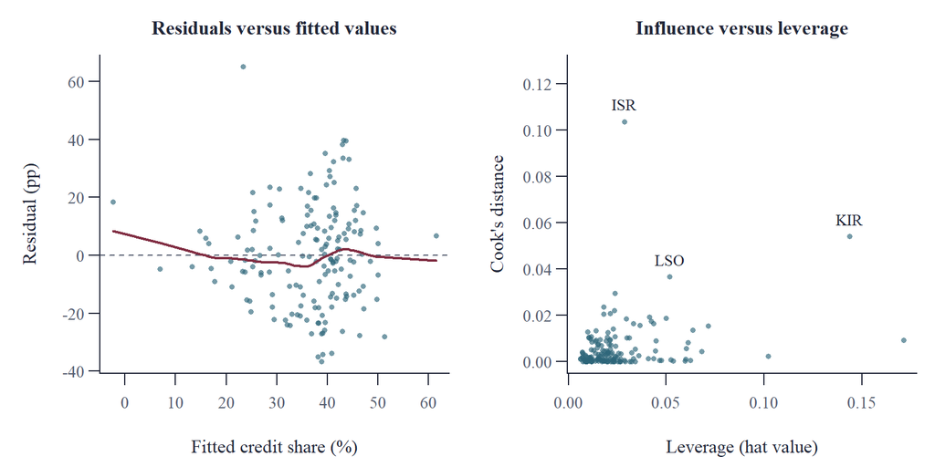

```r
old <- plot_start(c(1, 2))
plot(core_diagnostics$Fitted, core_diagnostics$Residual, pch = 16, cex = 0.65,
     col = adjustcolor(blue, alpha.f = 0.65), main = "Residuals versus fitted values",
     xlab = "Fitted credit share (%)", ylab = "Residual (pp)")
abline(h = 0, lty = 2, col = muted)
lines(lowess(core_diagnostics$Fitted, core_diagnostics$Residual), col = burgundy, lwd = 2)
plot(core_diagnostics$Leverage, core_diagnostics$Cook, pch = 16, cex = 0.65,
     col = adjustcolor(blue, alpha.f = 0.65), main = "Influence versus leverage",
     xlab = "Leverage (hat value)", ylab = "Cook's distance",
     ylim = c(0, max(core_diagnostics$Cook) * 1.23))
with(head(top_core_cook, 3), text(Leverage, Cook, labels = Economy, pos = 3, cex = 0.85))
```

```r
par(old)
```

A curved smoother can signal mean misspecification. Funnel-like spread can suggest unequal variance. Large leverage means the covariates are unusual. Cook’s distance combines leverage with residual size to indicate how much the fitted regression may change when a row is omitted. These observations prompt sensitivity refits. Automatically deleting them would change the sample and could discard meaningful variation.

```r
# RESET-style check: jointly test added powers of the fitted linear index.
tab(form_checks, "Fitted range and HC3 test of added fitted powers", digits = 4)
```

Fitted range and HC3 test of added fitted powers

| Model | Min fit | Max fit | Outside | F | df1 | df2 | p |
| --- | --- | --- | --- | --- | --- | --- | --- |
| Core | -2.3424 | 61.4801 | 1 | 1.5012 | 2 | 157 | 0.22603 |
| QoG origin | -2.6078 | 61.4547 | 1 | 3.0695 | 2 | 122 | 0.05005 |
| Full pitch terms | 4.5321 | 65.4045 | 0 | 2.0405 | 2 | 117 | 0.13457 |

The added fitted-powers test looks for systematic nonlinear information remaining in the residuals. Its null sets the coefficients on the squared and cubed fitted index to zero. Even a comfortable p-value leaves room for misspecification. The linear core produces **1** fitted value outside the feasible 0–100 range, so it is useful to check the result with a bounded conditional mean.

# 9 Challenge the result

## 9.1 Add regional, timing and development controls

Income is a plausible omitted confounder. It can be associated with credit depth, regulatory capacity and exposure to bribe requests. It is unmeasured in the approved analytical inputs. Region and survey cohort account for some shared differences. T5, the share of firms with their own website, probes a dimension of firm digital adoption. Website adoption can also respond to institutions and credit. The comparison therefore asks how the estimates move under different conditioning choices. It cannot isolate the income channel.

```r
# The same economies enter these specifications. Compare estimates with intervals.
adjustment_names <- c("Core", "Region controls", "Region and cohort controls",
                      "Firm websites added", "Region, cohort and websites")
adjustments <- sensitivity[match(adjustment_names, sensitivity$Model), ]
stopifnot(length(unique(adjustments$N)) == 1L)
tab(data.frame(Model = adjustments$Model, N = adjustments$N,
               Bribery_pp = adjustments$Bribery,
               HC3_interval = interval(adjustments$Bribe_low, adjustments$Bribe_high),
               p = adjustments$Bribe_p, check.names = FALSE),
    "Credit-share comparison for ten points more bribery, across specifications", digits = 3)
```

Credit-share comparison for ten points more bribery, across specifications

| Model | N | Bribery pp | HC3 interval | p |
| --- | --- | --- | --- | --- |
| Core | 163 | -7.056 | [-9.38, -4.73] | 1.29e-08 |
| Region controls | 163 | -3.323 | [-5.76, -0.88] | 0.0079 |
| Region and cohort controls | 163 | -2.808 | [-5.53, -0.08] | 0.0435 |
| Firm websites added | 163 | -2.912 | [-5.76, -0.06] | 0.0451 |
| Region, cohort and websites | 163 | -1.432 | [-4.14, 1.28] | 0.2976 |

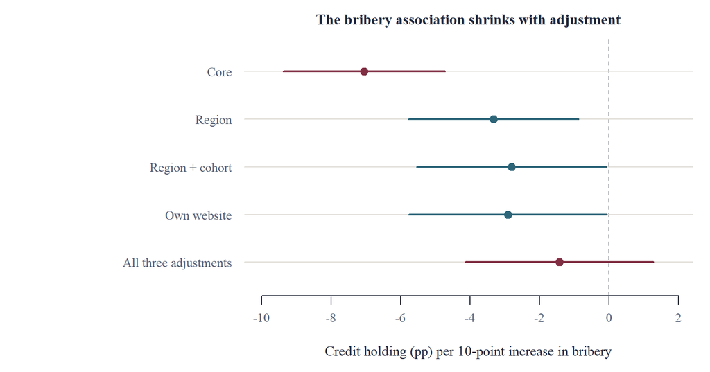

```r
old <- plot_start(margins = c(4.4, 14.1, 2.2, 1))
positions <- rev(seq_len(nrow(adjustments)))
lim <- range(c(adjustments$Bribe_low, adjustments$Bribe_high, 0)) + c(-0.65, 0.65)
plot(adjustments$Bribery, positions, type = "n", yaxt = "n", bty = "n",
     xlim = lim, ylim = c(0.5, max(positions) + 0.5),
     xlab = "Credit holding (pp) per 10-point increase in bribery", ylab = "",
     main = "The bribery association shrinks with adjustment")
axis(2, at = positions,
     labels = c("Core", "Region", "Region + cohort", "Own website", "All three adjustments"),
     tick = FALSE)
abline(v = 0, lty = 2, col = muted)
abline(h = positions, col = grid_col)
effect_colors <- c(burgundy, rep(blue, nrow(adjustments) - 2L), burgundy)
segments(adjustments$Bribe_low, positions, adjustments$Bribe_high, positions,
         lwd = 2, col = effect_colors)
points(adjustments$Bribery, positions, pch = 19, cex = 1.15, col = effect_colors)
```

```r
par(old)
```

The core estimate is -7.06 points. With all three adjustments it is -1.43 points, with interval [-4.14, 1.28]. Comparing two specifications answers a different question from comparing two p-values. Here both the size of the estimate and its precision change. The signed comparison between standardized court and bribery slopes also becomes imprecise under the combined adjustment.

```r
contrast_rows <- sensitivity_contrasts[match(
  c("Core", "Region and cohort controls", "Firm websites added", "Region, cohort and websites"),
  sensitivity_contrasts$Model), ]
tab(contrast_rows[c("Model", "Estimate", "Lower", "Upper", "p")],
    "Does the signed court-versus-bribery difference survive adjustment?", digits = 3)
```

Does the signed court-versus-bribery difference survive adjustment?

| Model | Estimate | Lower | Upper | p |
| --- | --- | --- | --- | --- |
| Core | 8.752 | 4.885 | 12.619 | 1.48e-05 |
| Region and cohort controls | 3.372 | -0.183 | 6.926 | 0.0629 |
| Firm websites added | 4.125 | -0.163 | 8.413 | 0.0593 |
| Region, cohort and websites | 1.676 | -2.141 | 5.492 | 0.3869 |

**What would it take for an omitted variable to erase the core association?**

The appendix uses an equal-strength partial-R² benchmark. It asks how much residual variation a hypothetical variable would need to explain in both the regressor and outcome equations to move the point estimate to zero in the adverse direction. This is a model-based calibration of the omitted-variable problem. It does not measure national income or establish that the core coefficient is causal.

```r
benchmark <- confounding
benchmark$Term <- term_labels(benchmark$Term)
tab(benchmark, "Compare an omitted-variable benchmark with observed website adoption", digits = 3)
```

Compare an omitted-variable benchmark with observed website adoption

| Term | Equal partial R2 | Website with regressor | Website with credit | Website N |
| --- | --- | --- | --- | --- |
| Court doubt | 0.060 | 0.000 | 0.303 | 163 |
| Bribery incidence | 0.345 | 0.171 | 0.303 | 163 |

## 9.2 Give the outcome and the sample another chance

Fractional logit models the conditional mean of FIN14 divided by 100 as a logistic function. Its fitted shares stay within zero and one. To compare with OLS we transform predictions back to percentage points, change one regressor, and average the prediction differences across economies. The numbers below use the pipeline’s leverage-adjusted sandwich covariance and a delta-method interval for the nonlinear prediction difference. [Papke and Wooldridge, *Journal of Applied Econometrics*](https://doi.org/10.1002/%28SICI%291099-1255%28199611%2911%3A6%3C619%3A%3AAID-JAE418%3E3.0.CO%3B2-1)

```r
# Reproduce the average fitted difference for a 10-point increase in bribery.
# This is a prediction contrast evaluated on the same observed economies.
shifted <- transform(study, GRAFT3 = GRAFT3 + 10)
frac_rebuilt <- 100 * mean(predict(fractional, shifted, type = "response") -
                             predict(fractional, study, type = "response"))
frac_bribe <- subset(fractional_changes, Term == "GRAFT3")
stopifnot(isTRUE(all.equal(frac_rebuilt, frac_bribe$Estimate, tolerance = 1e-8)))
tab(data.frame(Model = c("Core OLS", "Fractional logit"),
               Estimate = c(main_bribery$Estimate, frac_rebuilt),
               Lower = c(main_bribery$Lower, frac_bribe$Lower),
               Upper = c(main_bribery$Upper, frac_bribe$Upper)),
    "Linear and bounded models · credit holding per ten points more bribery")
```

Linear and bounded models · credit holding per ten points more bribery

| Model | Estimate | Lower | Upper |
| --- | --- | --- | --- |
| Core OLS | -7.06 | -9.38 | -4.73 |
| Fractional logit | -7.47 | -9.89 | -5.05 |

The bounded fit preserves the negative association on the core covariate set. The two models assume different mean functions. Their agreement says something about functional-form sensitivity; it leaves confounding and the choice of controls open.

```r
# Each row changes the feature in its label. The alternate FIN23 outcome
# measures constraint, so its coefficient is a difference in the constrained share.
check_names <- c("Workers in levels", "Surveys from 2023", "Surveys from 2024",
                 "Court obstacle, recent", "Court obstacle, all vintages",
                 "Fully credit constrained", "Full pitch terms, QoG codes",
                 paste("Omit", influence_cases))
stress <- sensitivity[match(check_names, sensitivity$Model), ]
tab(data.frame(Check = stress$Model, N = stress$N,
               Outcome = ifelse(stress$Model == "Fully credit constrained", "FIN23", "FIN14"),
               Court_measure = stress$Court_measure, Court_pp = stress$Court,
               Court_95_CI = interval(stress$Court_low, stress$Court_high),
               Bribery_pp = stress$Bribery,
               Bribery_95_CI = interval(stress$Bribe_low, stress$Bribe_high)),
    "Sensitivity to measures, waves, specification and influential economies")
```

Sensitivity to measures, waves, specification and influential economies

| Check | N | Outcome | Court measure | Court pp | Court 95 CI | Bribery pp | Bribery 95 CI |
| --- | --- | --- | --- | --- | --- | --- | --- |
| Workers in levels | 163 | FIN14 | BREADY_DISP3 | 0.35 | [-1.39, 2.10] | -7.26 | [-9.49, -5.02] |
| Surveys from 2023 | 158 | FIN14 | BREADY_DISP3 | 0.79 | [-0.95, 2.54] | -6.77 | [-9.31, -4.23] |
| Surveys from 2024 | 113 | FIN14 | BREADY_DISP3 | 0.26 | [-1.87, 2.40] | -6.00 | [-9.02, -2.99] |
| Court obstacle, recent | 163 | FIN14 | CRIME9 | 0.62 | [-2.43, 3.66] | -6.97 | [-9.62, -4.32] |
| Court obstacle, all vintages | 181 | FIN14 | CRIME9 | 1.03 | [-1.52, 3.58] | -6.76 | [-9.01, -4.51] |
| Fully credit constrained | 163 | FIN23 | BREADY_DISP3 | 0.01 | [-1.25, 1.27] | 4.57 | [2.14, 7.01] |
| Full pitch terms, QoG codes | 129 | FIN14 | BREADY_DISP3 | 0.41 | [-2.37, 3.20] | -4.62 | [-7.64, -1.60] |
| Omit ISR | 162 | FIN14 | BREADY_DISP3 | 0.43 | [-1.27, 2.13] | -7.58 | [-9.74, -5.43] |
| Omit KIR | 162 | FIN14 | BREADY_DISP3 | 0.88 | [-0.86, 2.62] | -7.53 | [-9.85, -5.21] |
| Omit GTM | 162 | FIN14 | BREADY_DISP3 | 0.58 | [-1.26, 2.42] | -7.03 | [-9.34, -4.72] |

In the narrower samples and the court-obstacle alternatives, the court intervals continue to include zero. The core bribery associations persist when the selected influential economies are left out one at a time. With FIN23, more bribery is associated with a larger fully credit-constrained share. FIN23 classifies firms using financing sources and application or nonapplication information. Read the sign as more constraint in that distinct outcome. The supplemental regressions are diagnostic comparisons. Their intervals are pointwise and the reported p-values carry no multiple-comparisons adjustment.

# 10 Draw conclusions from the chain of evidence

The raw survey rows determine which firms and waves the study describes. The simple model asks whether court doubt alone explains much of the difference in credit holding. The core model compares economies with similar reported bribery exposure and firm size, and the legal-origin extension compares documented historical categories. The diagnostics show why HC3 and bounded-response checks are worthwhile. The sensitivity to geography and digital adoption changes the strength of the substantive conclusion.

### Court perceptions

The point estimate changes sign after adding controls. The intervals still admit both signs. We learn that the measured perception indicator provides little precise evidence about credit holding in these specifications.

### Bribery

The association is large in the core model and survives several measurement and influence checks. The adjusted comparison is materially smaller and imprecise. Its strength depends on the specification.

### Legal origin

The conditional differences are imprecise whether English common law is compared with all documented other origins or with named civil-code families. Classifications and geography shape the sample.

For a bank, the results suggest which inputs would be worth measuring directly when evaluating recovery and underwriting: recovery times, collateral enforceability, application rates and reasons for rejection. For policymakers and business associations, the negative core bribery association helps identify public transactions to study alongside application and financing outcomes. The study cannot rank the return on court reform against the return on anti-bribery policy. Establishing those returns would require linked outcomes and a design that isolates institutional changes from simultaneous differences in income, financial markets and firms’ choices.

## 10.1 Check your understanding

**Why can a significantly negative bribery slope coexist with an inconclusive comparison to court doubt?**

The individual test uses one slope and its variance. The direct comparison uses the two scaled slopes and their covariance. An interval for their difference can include zero even if one individual interval excludes zero.

**Why repeat the core equation on the legal-origin sample?**

Adding the dummy also removes observations with unavailable classification. The fixed-sample refit lets us see how the model changes when we add the dummy, given the restriction to the classified sample.

**Would reordering the economies change the finance conclusion?**

It changes which residual pairs are adjacent for Durbin–Watson. It leaves the OLS coefficients and row-specific fitted values the same. Dependence across regions warrants different checks from a time-series ordering.

**Does a large in-sample $R^2$ settle whether a model is suitable for policy?**

Fit describes how well the regressors account for variation in the observed outcome. A regressor may improve fit because it reflects an outcome of the same lending process. Policy interpretation also requires a credible design and a well-defined comparison.

## 10.2 Brief checklist and reproducibility

```r
tab(data.frame(
  Brief = c("Population regression function and CLRM", "Multivariate specification and fit",
            "Qualitative variable", "Diagnostics and corrective measures",
            "Tests and economic interpretation"),
  Where = c("Fit the first regression", "Extend the model", "Add a legal-origin dummy carefully",
            "Diagnose the model; Challenge the result", "Test the claims; Draw conclusions")
), "Where to find each commissioned methods item")
```

Where to find each commissioned methods item

| Brief | Where |
| --- | --- |
| Population regression function and CLRM | Fit the first regression |
| Multivariate specification and fit | Extend the model |
| Qualitative variable | Add a legal-origin dummy carefully |
| Diagnostics and corrective measures | Diagnose the model; Challenge the result |
| Tests and economic interpretation | Test the claims; Draw conclusions |

The notebook uses the same data, model functions and estimates as the paper and the PDF appendix. Its visible examples recalculate key quantities and check that they agree with the pipeline. To regenerate the notebook from the repository root, run `Rscript --vanilla scripts/notebook.R`. With the R packages on your library path, the equivalent in the RStudio console is `rmarkdown::render("notebook/notebook.Rmd")`. The HTML code menu can show or hide every chunk and download the embedded R Markdown source. A full rerun uses the files in the repository.

```r
# Analysis stages are sourced in order by scripts/build.R.
stage_notes <- c("01_data.R" = "National totals, wave alignment and sample audit",
                 "02_models.R" = "OLS fits, HC3 tests and contrasts",
                 "03_diagnostics.R" = "Variance, order, collinearity and influence checks",
                 "04_sensitivity.R" = "Alternative specifications and fractional response",
                 "05_court_comparisons.R" = "Named country examples, court confidence and repeat-wave comparisons")
tab(data.frame(Stage = names(stage_notes), Purpose = unname(stage_notes)),
    "Analysis stages used in this notebook")
```

Analysis stages used in this notebook

| Stage | Purpose |
| --- | --- |
| 01_data.R | National totals, wave alignment and sample audit |
| 02_models.R | OLS fits, HC3 tests and contrasts |
| 03_diagnostics.R | Variance, order, collinearity and influence checks |
| 04_sensitivity.R | Alternative specifications and fractional response |
| 05_court_comparisons.R | Named country examples, court confidence and repeat-wave comparisons |

```r
R.version.string
```

```
#> [1] "R version 4.6.1 (2026-06-24 ucrt)"
```

[output not shown]

```r
packageVersion("rmarkdown")
```

```
#> [1] '2.32'
```

```r
packageVersion("knitr")
```

```
#> [1] '1.52'
```

**Primary data and study context.** [World Bank Data360 Enterprise Surveys](https://data360.worldbank.org/en/dataset/WB_ES), [survey methodology](https://www.enterprisesurveys.org/en/methodology), [indicator definitions](https://www.enterprisesurveys.org/content/dam/enterprisesurveys/documents/methodology/Indicator-Description.pdf), [QoG Standard data and citation](https://doi.org/10.18157/qogstdjan22), [La Porta et al. on legal origins](https://doi.org/10.1257/jel.46.2.285).